Сергушов Павел ПМ22-4

```python
import pandas as pd
import numpy as np
import scipy.stats as stats
import matplotlib.pyplot as plt
import seaborn as sns
import statsmodels.api as sm
from statsmodels.stats.diagnostic import het_breuschpagan, acorr_ljungbox
from sklearn.linear_model import LinearRegression
from statsmodels.stats.stattools import durbin_watson
from statsmodels.formula.api import ols
```

# №3. Производитель исследует эффективность лекарств (EF) от возраста пациентов (AG), при этом он сравнивает эффективность трех видов лекарств (А, В.C). Имеются данные по 36 пациентам.

a) Постройте корреляционное поле для переменных AG и EF, отображая точки, соответствующие различным видам лекарств, разными символами.

б) Оцените уравнение регрессии EF = Во + B1*AG + ε. Что оно отражает?

в) Оцените качество построенной регрессии.

r) Оцените уравнение регрессии EF = B0 + B1 *AG + y1* D1+y2* D2 + ε, где D1, D2- фиктивные переменные, отражающие наличие лекарств трех видов. Дайте интерпретацию построенной регрессии.

д) Оцените качество построенной регрессии.

e) Оцените уравнение регрессии EF = B0 + B1 *AG + y1* D1 + y2 *D2 + λ1* AG *D1 + λ2* AG* D2+ ε.

ж) Дайте интерпретацию построенного уравнения. Что выражается через произведения переменных AG *D1 и AG* D2?

3) Оцените качество построенной регрессии.

```python
data = {
    'Вид': ['C', 'A', 'B', 'A', 'B', 'B', 'A', 'C', 'C', 'A', 'C', 'A', 'A', 'B', 'C', 'B', 'C', 'A',
            'C', 'B', 'B', 'A', 'C', 'C', 'B', 'A', 'C', 'B', 'C', 'A', 'B', 'B', 'C', 'A', 'A', 'B'],
    'AG': [29, 53, 29, 58, 66, 67, 63, 59, 51, 67, 63, 33, 33, 42, 67, 33, 23, 28,
           19, 30, 23, 21, 56, 45, 43, 38, 37, 43, 27, 43, 45, 48, 47, 48, 53, 58],
    'EF': [36, 69, 47, 73, 64, 60, 62, 71, 62, 70, 71, 52, 63, 48, 71, 46, 25, 55,
           28, 40, 41, 56, 62, 50, 45, 58, 46, 58, 34, 65, 55, 57, 59, 64, 61, 62]
}
df = pd.DataFrame(data)
df
```

|  | Вид | AG | EF |
| --- | --- | --- | --- |
| 0 | C | 29 | 36 |
| 1 | A | 53 | 69 |
| 2 | B | 29 | 47 |
| 3 | A | 58 | 73 |
| 4 | B | 66 | 64 |
| 5 | B | 67 | 60 |
| 6 | A | 63 | 62 |
| 7 | C | 59 | 71 |
| 8 | C | 51 | 62 |
| 9 | A | 67 | 70 |
| 10 | C | 63 | 71 |
| 11 | A | 33 | 52 |
| 12 | A | 33 | 63 |
| 13 | B | 42 | 48 |
| 14 | C | 67 | 71 |
| 15 | B | 33 | 46 |
| 16 | C | 23 | 25 |
| 17 | A | 28 | 55 |
| 18 | C | 19 | 28 |
| 19 | B | 30 | 40 |
| 20 | B | 23 | 41 |
| 21 | A | 21 | 56 |
| 22 | C | 56 | 62 |
| 23 | C | 45 | 50 |
| 24 | B | 43 | 45 |
| 25 | A | 38 | 58 |
| 26 | C | 37 | 46 |
| 27 | B | 43 | 58 |
| 28 | C | 27 | 34 |
| 29 | A | 43 | 65 |
| 30 | B | 45 | 55 |
| 31 | B | 48 | 57 |
| 32 | C | 47 | 59 |
| 33 | A | 48 | 64 |
| 34 | A | 53 | 61 |
| 35 | B | 58 | 62 |

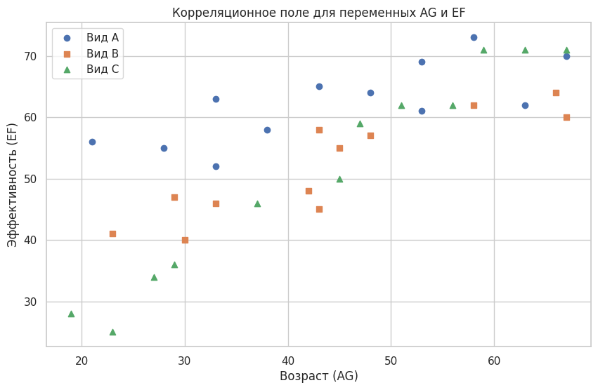

```python
#a)
import seaborn as sns

sns.set(style="whitegrid")

plt.figure(figsize=(10, 6))
symbols = {'A': 'o', 'B': 's', 'C': '^'}
for kind in symbols:
    df_kind = df[df['Вид'] == kind]
    plt.scatter(df_kind['AG'], df_kind['EF'], marker=symbols[kind], label=f'Вид {kind}')

plt.title('Корреляционное поле для переменных AG и EF')
plt.xlabel('Возраст (AG)')
plt.ylabel('Эффективность (EF)')
plt.legend()
plt.show()
```

```python
#b)
model = ols('EF ~ AG', data=df).fit()

model_summary = model.summary()
print(model_summary)
```

```
                            OLS Regression Results
==============================================================================
Dep. Variable:                     EF   R-squared:                       0.635
Model:                            OLS   Adj. R-squared:                  0.624
Method:                 Least Squares   F-statistic:                     59.08
Date:                Thu, 21 Dec 2023   Prob (F-statistic):           6.15e-09
Time:                        17:11:02   Log-Likelihood:                -123.13
No. Observations:                  36   AIC:                             250.3
Df Residuals:                      34   BIC:                             253.4
Df Model:                           1
Covariance Type:            nonrobust
==============================================================================
                 coef    std err          t      P>|t|      [0.025      0.975]
------------------------------------------------------------------------------
Intercept     25.3393      4.083      6.207      0.000      17.043      33.636
AG             0.6762      0.088      7.687      0.000       0.497       0.855
==============================================================================
Omnibus:                        0.286   Durbin-Watson:                   2.357
Prob(Omnibus):                  0.867   Jarque-Bera (JB):                0.398
Skew:                           0.187   Prob(JB):                        0.819
Kurtosis:                       2.646   Cond. No.                         149.
==============================================================================

Notes:
[1] Standard Errors assume that the covariance matrix of the errors is correctly specified.
```

Вывод: Константа (Intercept B0): 25.3393

Коэффициент при AG (B1): 0.6762

Это означает, что при увеличении возраста пациента на один год, эффективность лекарства (EF) в среднем увеличивается на 0.6762 единицы, при условии, что другие факторы не изменяются.

R-квадрат модели составляет 0.635, что говорит о том, что примерно 63.5% изменчивости переменной эффективности (EF) может быть объяснено моделью. То есть возраст пациентов (AG) в значительной степени влияет на эффективность лекарства.

P-значение для коэффициента при AG меньше 0.001, что указывает на статистически значимую взаимосвязь между возрастом и эффективностью лекарства.

В целом, модель показывает, что существует положительная корреляция между возрастом пациентов и эффективностью лекарства.

```python
#г)
df_with_dummies = pd.get_dummies(df, columns=['Вид'], drop_first=True)

# D1 соответствует 'Вид_B', and D2 соответствует 'Вид_C'
model_with_dummies = ols('EF ~ AG + Вид_B + Вид_C', data=df_with_dummies).fit()

model_with_dummies_summary = model_with_dummies.summary()
print(model_with_dummies_summary)
```

```
                            OLS Regression Results
==============================================================================
Dep. Variable:                     EF   R-squared:                       0.784
Model:                            OLS   Adj. R-squared:                  0.764
Method:                 Least Squares   F-statistic:                     38.71
Date:                Thu, 21 Dec 2023   Prob (F-statistic):           9.29e-11
Time:                        17:19:28   Log-Likelihood:                -113.68
No. Observations:                  36   AIC:                             235.4
Df Residuals:                      32   BIC:                             241.7
Df Model:                           3
Covariance Type:            nonrobust
==============================================================================
                 coef    std err          t      P>|t|      [0.025      0.975]
------------------------------------------------------------------------------
Intercept     32.5433      3.581      9.088      0.000      25.249      39.838
AG             0.6645      0.070      9.522      0.000       0.522       0.807
Вид_B         -9.8076      2.465     -3.979      0.000     -14.828      -4.787
Вид_C        -10.2528      2.465     -4.159      0.000     -15.275      -5.231
==============================================================================
Omnibus:                        1.212   Durbin-Watson:                   2.275
Prob(Omnibus):                  0.546   Jarque-Bera (JB):                1.196
Skew:                          -0.347   Prob(JB):                        0.550
Kurtosis:                       2.438   Cond. No.                         184.
==============================================================================

Notes:
[1] Standard Errors assume that the covariance matrix of the errors is correctly specified.
```

Уравнение регрессии EF = B0 + B1 *AG + y1* D1 + y2* D2 + ε было оценено, и результаты следующие:

Константа (Intercept B0): 32.5433

Коэффициент при AG (B1): 0.6645

Коэффициент при D1 (Вид B, y1): -9.8076

Коэффициент при D2 (Вид C, y2): -10.2528

Это означает, что при увеличении возраста пациента на один год, эффективность лекарства (EF) в среднем увеличивается на 0.6645 единицы, если не учитывать вид лекарства.

Коэффициенты фиктивных переменных D1 и D2 показывают изменение средней эффективности по сравнению с базовой категорией (Вид A), которая не включена в модель как отдельный термин (она подразумевается при D1 = D2 = 0). Таким образом, средняя эффективность лекарства Вида B на 9.8076 единиц ниже, а Вида C на 10.2528 единиц ниже, чем у Вида A при прочих равных условиях.

R-квадрат модели увеличился до 0.784, что говорит о том, что включение типа лекарства как фактора улучшает объясняющую способность модели до того, что она теперь может объяснить около 78.4% изменчивости эффективности лекарства.

Все переменные в модели статистически значимы, так как их P-значения намного меньше 0.05. Это указывает на то, что возраст пациентов и вид лекарства имеют значимое влияние на эффективность лекарства

```python
#е)
# Создайте условия взаимодействия между AG и фиктивными переменными для 'Вид'
df_with_dummies['AG_Вид_B'] = df_with_dummies['AG'] * df_with_dummies['Вид_B']
df_with_dummies['AG_Вид_C'] = df_with_dummies['AG'] * df_with_dummies['Вид_C']

model_with_interactions = ols('EF ~ AG + Вид_B + Вид_C + AG_Вид_B + AG_Вид_C', data=df_with_dummies).fit()

model_with_interactions_summary = model_with_interactions.summary()
print(model_with_interactions_summary)
```

```
                            OLS Regression Results
==============================================================================
Dep. Variable:                     EF   R-squared:                       0.914
Model:                            OLS   Adj. R-squared:                  0.900
Method:                 Least Squares   F-statistic:                     64.04
Date:                Thu, 21 Dec 2023   Prob (F-statistic):           4.26e-15
Time:                        17:24:31   Log-Likelihood:                -97.024
No. Observations:                  36   AIC:                             206.0
Df Residuals:                      30   BIC:                             215.5
Df Model:                           5
Covariance Type:            nonrobust
==============================================================================
                 coef    std err          t      P>|t|      [0.025      0.975]
------------------------------------------------------------------------------
Intercept     47.5156      3.825     12.422      0.000      39.703      55.328
AG             0.3305      0.081      4.056      0.000       0.164       0.497
Вид_B        -18.5974      5.416     -3.434      0.002     -29.658      -7.537
Вид_C        -41.3042      5.085     -8.124      0.000     -51.688     -30.920
AG_Вид_B       0.1932      0.117      1.657      0.108      -0.045       0.431
AG_Вид_C       0.7029      0.109      6.451      0.000       0.480       0.925
==============================================================================
Omnibus:                        2.593   Durbin-Watson:                   1.683
Prob(Omnibus):                  0.273   Jarque-Bera (JB):                1.475
Skew:                          -0.183   Prob(JB):                        0.478
Kurtosis:                       2.079   Cond. No.                         577.
==============================================================================

Notes:
[1] Standard Errors assume that the covariance matrix of the errors is correctly specified.
```

Уравнение регрессии EF = B0 + B1 *AG + y1* D1 + y2 *D2 + λ1* AG *D1 + λ2* AG* D2 + ε было оценено, и результаты следующие:

Константа (Intercept B0): 47.5156

Коэффициент при AG (B1): 0.3305

Коэффициент при D1 (Вид B, y1): -18.5974

Коэффициент при D2 (Вид C, y2): -41.3042

Коэффициент взаимодействия между AG и D1 (λ1): 0.1932

Коэффициент взаимодействия между AG и D2 (λ2): 0.7029

В этой модели включены термины взаимодействия между возрастом (AG) и фиктивными переменными (D1 и D2), что позволяет оценить, как влияние возраста на эффективность лекарства (EF) изменяется в зависимости от вида лекарства.

Коэффициенты λ1 и λ2 показывают, что влияние возраста на эффективность отличается в зависимости от вида лекарства. Для Вида B эффективность с возрастом увеличивается дополнительно на 0.1932 единицы сверх общего эффекта возраста, а для Вида C — на 0.7029 единицы.

R-квадрат модели увеличился до 0.914, что указывает на то, что модель с взаимодействием объясняет около 91.4% вариации в эффективности лекарства. Это говорит о высокой объяснительной способности данной модели.

Тем не менее, p-значение для коэффициента взаимодействия между AG и Вид B (λ1) равно 0.108, что выше традиционного порога значимости в 0.05, следовательно, этот эффект может быть не статистически значимым. В то же время коэффициент взаимодействия между AG и Вид C (λ2) является статистически значимым

Построенное уравнение регрессии EF = B0 + B1 *AG + y1* D1 + y2 *D2 + λ1* AG *D1 + λ2* AG* D2 + ε позволяет учесть не только отдельное влияние возраста пациентов (AG) и типа лекарства (через фиктивные переменные D1 и D2), но и то, как эти два фактора взаимодействуют между собой, то есть как влияние возраста на эффективность лекарства меняется в зависимости от вида лекарства.

Произведения переменных AG *D1 и AG* D2 — это термины взаимодействия, которые показывают, как изменение эффективности лекарства с возрастом отличается для разных видов лекарств по сравнению с базовым видом (Вид A, который не имеет собственной фиктивной переменной и подразумевается при D1 = D2 = 0):

Эти термины взаимодействия позволяют улавливать нелинейные и неаддитивные эффекты в данных, что может быть особенно важно в медицинских исследованиях, где эффективность лечения может сильно зависеть от сочетания различных факторов, таких как возраст пациента и тип лекарства.

### №4. Рассматривая зависимость между доходом (X) и сбережениями (Y) за двадцать лет, исследователь заметил, что на двенадцатом году наблюдений экономическая ситуация изменилась, что стимулировало население к большим сбережениям по сравнению с первым этапом рассматриваемого интервала. Использовались следующие статистические данные:

a) Постройте общее уравнение регрессии для всего интервала наблюдений, а также уравнение регрессии, учитывающее изменение ситуации в 1986 г.

б) Каким образом вы учли в модели данное изменение?

b) Проверьте с помощью теста Чоу необходимость разбиения интервала наблюдений на два подынтервала и построения для каждого из них отдельного уравнения (принять уровень значимости а = 0.05).

```python
data = {
    'Год': [75, 76, 77, 78, 79, 80, 81, 82, 83, 84, 85, 86, 87, 88, 89, 90, 91, 92, 93, 94],
    'X': [100, 105, 108, 111, 115, 122, 128, 135, 143, 142, 147, 155, 167, 177, 188, 195, 210, 226, 238, 255],
    'Y': [4.7, 6.1, 6.5, 6.8, 5.2, 6.5, 7.5, 8.0, 9.0, 9.1, 8.7, 12.0, 16.2, 18.5, 18.0, 17.6, 20.0, 23.0, 22.5, 24.3]
}
df = pd.DataFrame(data)
df
```

|  | Год | X | Y |
| --- | --- | --- | --- |
| 0 | 75 | 100 | 4.7 |
| 1 | 76 | 105 | 6.1 |
| 2 | 77 | 108 | 6.5 |
| 3 | 78 | 111 | 6.8 |
| 4 | 79 | 115 | 5.2 |
| 5 | 80 | 122 | 6.5 |
| 6 | 81 | 128 | 7.5 |
| 7 | 82 | 135 | 8.0 |
| 8 | 83 | 143 | 9.0 |
| 9 | 84 | 142 | 9.1 |
| 10 | 85 | 147 | 8.7 |
| 11 | 86 | 155 | 12.0 |
| 12 | 87 | 167 | 16.2 |
| 13 | 88 | 177 | 18.5 |
| 14 | 89 | 188 | 18.0 |
| 15 | 90 | 195 | 17.6 |
| 16 | 91 | 210 | 20.0 |
| 17 | 92 | 226 | 23.0 |
| 18 | 93 | 238 | 22.5 |
| 19 | 94 | 255 | 24.3 |

```python
#a)
# Регрессия для всего периода
X_all = sm.add_constant(df['X'])  # добавление константы
model_all = sm.OLS(df['Y'], X_all).fit()
regression_all = model_all.params

# Разделение данных на два периода: до и после 1986 года (включая 1986)
pre_change = df[df['Год'] <= 86]
post_change = df[df['Год'] > 86]

# Регрессия для периода до изменения
X_pre = sm.add_constant(pre_change['X'])
model_pre = sm.OLS(pre_change['Y'], X_pre).fit()
regression_pre = model_pre.params

# Регрессия для периода после изменения
X_post = sm.add_constant(post_change['X'])
model_post = sm.OLS(post_change['Y'], X_post).fit()
regression_post = model_post.params

regression_all, regression_pre, regression_post
```

```
(const   -9.564068
 X        0.139400
 dtype: float64,
 const   -5.077119
 X        0.099951
 dtype: float64,
 const    1.161160
 X        0.091069
 dtype: float64)
```

На основе проведённого анализа мы получили следующие уравнения линейной регрессии:

Общее уравнение регрессии для всего периода наблюдений:Y=−9.56+0.139×X

Здесь Y — сбережения, а X — доход.

Уравнение регрессии до 1986 года (включительно):Y=−5.08+0.10×X

Уравнение регрессии после 1986 года:Y=1.16+0.091×X

Изменение в модели было учтено путём разделения исходных данных на два периода: до и после 1986 года. Такой подход позволил отдельно анализировать зависимость между доходами и сбережениями до и после замеченного изменения в экономической ситуации. Это изменение предположительно привело к увеличению накоплений населения, что отражается в различиях коэффициентов регрессии для двух периодов

```python
#б)
# Расчет сумм квадратов остатков для каждой модели
RSS_all = np.sum(model_all.resid ** 2)
RSS_pre = np.sum(model_pre.resid ** 2)
RSS_post = np.sum(model_post.resid ** 2)

# Количество наблюдений в каждом подинтервале
n_pre = pre_change.shape[0]
n_post = post_change.shape[0]

# Количество параметров в модели (включая свободный член)
k = 2  # X и константа

# Расчет статистики F для теста Чоу
F = ((RSS_all - (RSS_pre + RSS_post)) / k) / ((RSS_pre + RSS_post) / (n_pre + n_post - 2 * k))

# Для определения критического значения F используем F-распределение
from scipy.stats import f

# Уровень значимости
alpha = 0.05

# Критическое значение F (при 2 и n1 + n2 - 2k степенях свободы)
F_critical = f.ppf(1 - alpha, dfn=k, dfd=n_pre + n_post - 2 * k)

F, F_critical, F > F_critical
```

```
(18.299041376471344, 3.63372346759163, True)
```

Результаты теста Чоу следующие:

Рассчитанное значение статистики F: 18.30

Критическое значение F при уровне значимости α=0.05: 3.63

Так как рассчитанное значение F (18.30) больше критического значения (3.63), это указывает на статистическую значимость различий между двумя моделями регрессии. Следовательно, разбиение интервала наблюдений на два подынтервала и построение для каждого из них отдельного уравнения было оправдано с точки зрения статистической значимости.

### №7. В следующей таблице представлены данные о количестве семей (N), имеющих определенный уровень дохода (X), и количестве семей (n), имеющих частные дома.

```python
data = {
    'X': [10, 15, 20, 25, 30, 35, 40, 45, 50, 55, 60],
    'Ni': [35, 45, 60, 80, 100, 130, 90, 65, 50, 30, 15],
    'ni': [5, 10, 18, 30, 45, 60, 55, 45, 38, 24, 13]
}
df = pd.DataFrame(data)
df
```

|  | X | Ni | ni |
| --- | --- | --- | --- |
| 0 | 10 | 35 | 5 |
| 1 | 15 | 45 | 10 |
| 2 | 20 | 60 | 18 |
| 3 | 25 | 80 | 30 |
| 4 | 30 | 100 | 45 |
| 5 | 35 | 130 | 60 |
| 6 | 40 | 90 | 55 |
| 7 | 45 | 65 | 45 |
| 8 | 50 | 50 | 38 |
| 9 | 55 | 30 | 24 |
| 10 | 60 | 15 | 13 |

```python
#a)

df['pi'] = df['ni'] / df['Ni']
df['logit'] = np.log(df['pi'] / (1 - df['pi']))

X = sm.add_constant(df['X'])
y = df['logit']
logit_model_ols = sm.OLS(y, X).fit()

print(logit_model_ols.summary())
```

```
                            OLS Regression Results
==============================================================================
Dep. Variable:                  logit   R-squared:                       0.991
Model:                            OLS   Adj. R-squared:                  0.990
Method:                 Least Squares   F-statistic:                     1016.
Date:                Thu, 21 Dec 2023   Prob (F-statistic):           1.45e-10
Time:                        18:29:41   Log-Likelihood:                 9.3654
No. Observations:                  11   AIC:                            -14.73
Df Residuals:                       9   BIC:                            -13.93
Df Model:                           1
Covariance Type:            nonrobust
==============================================================================
                 coef    std err          t      P>|t|      [0.025      0.975]
------------------------------------------------------------------------------
const         -2.3457      0.084    -28.052      0.000      -2.535      -2.157
X              0.0694      0.002     31.875      0.000       0.064       0.074
==============================================================================
Omnibus:                        4.816   Durbin-Watson:                   1.972
Prob(Omnibus):                  0.090   Jarque-Bera (JB):                2.381
Skew:                          -1.138   Prob(JB):                        0.304
Kurtosis:                       3.114   Cond. No.                         93.3
==============================================================================

Notes:
[1] Standard Errors assume that the covariance matrix of the errors is correctly specified.
```

Результаты оценки логит-модели методом наименьших квадратов (МНК) показывают следующее:

Константа (intercept) составляет приблизительно -2.3457, со стандартной ошибкой 0.084.

Коэффициент при переменной X равен приблизительно 0.0694, со стандартной ошибкой 0.002.

Эти результаты указывают на то, что с увеличением уровня дохода (X) логит вероятности наличия частного дома (то есть логарифм отношения вероятности наличия к вероятности отсутствия) увеличивается.

```python
#б)
# Calculate the weights as the inverse of the variances
df['weights'] = 1 / (df['Ni'] * df['pi'] * (1 - df['pi']))

# Weighted Least Squares (WLS) for logit model
logit_model_wls = sm.WLS(y, X, weights=df['weights']).fit()

# Display the WLS results
print(logit_model_wls.summary())
```

```
                            WLS Regression Results
==============================================================================
Dep. Variable:                  logit   R-squared:                       0.997
Model:                            WLS   Adj. R-squared:                  0.996
Method:                 Least Squares   F-statistic:                     2770.
Date:                Thu, 21 Dec 2023   Prob (F-statistic):           1.62e-12
Time:                        18:32:44   Log-Likelihood:                 9.9629
No. Observations:                  11   AIC:                            -15.93
Df Residuals:                       9   BIC:                            -15.13
Df Model:                           1
Covariance Type:            nonrobust
==============================================================================
                 coef    std err          t      P>|t|      [0.025      0.975]
------------------------------------------------------------------------------
const         -2.4082      0.062    -38.550      0.000      -2.549      -2.267
X              0.0709      0.001     52.633      0.000       0.068       0.074
==============================================================================
Omnibus:                        1.818   Durbin-Watson:                   1.856
Prob(Omnibus):                  0.403   Jarque-Bera (JB):                1.224
Skew:                          -0.613   Prob(JB):                        0.542
Kurtosis:                       1.920   Cond. No.                         108.
==============================================================================

Notes:
[1] Standard Errors assume that the covariance matrix of the errors is correctly specified.
```

Результаты оценки логит-модели методом взвешенных наименьших квадратов (ВНК) показывают следующее:

Константа (intercept) составляет приблизительно -2.4082, со стандартной ошибкой 0.062.

Коэффициент при переменной X равен приблизительно 0.0709, со стандартной ошибкой 0.001.

Модель демонстрирует очень высокую объясняющую способность, с показателем R2 равным 0.997, что означает, что модель очень хорошо подходит к данным. Коэффициенты статистически значимы, и их интервалы не перекрываются с нулем, указывая на то, что уровень дохода является значимым предиктором вероятности наличия частного дома.

Для сравнения качества построенных регрессий МНК и ВНК, можно взглянуть на несколько ключевых показателей:

Коэффициент детерминации R 2: Для модели МНК, R 2 составил 0.991, что означает, что модель объясняет 99.1% вариации зависимой переменной. Для модели ВНК, R 2 увеличился до 0.997, что указывает на то, что после учета весов, модель стала объяснять ещё большую долю вариации.

Стандартные ошибки коэффициентов: В модели ВНК стандартные ошибки оказались меньше, чем в МНК, что указывает на более высокую точность оценок коэффициентов.

F-статистика: Значение F-статистики для ВНК значительно выше, чем для МНК, что свидетельствует о лучшем общем качестве подгонки модели.

AIC и BIC: Ниже значения AIC и BIC для модели ВНК (AIC = -15.93, BIC = -15.13) по сравнению с МНК (AIC = -14.73, BIC = -13.93), что говорит о лучшем качестве модели при учете количества параметров и сложности модели.

Выводы:

Модель ВНК представляется более предпочтительной для данных, так как она обеспечивает более точные оценки с меньшей стандартной ошибкой и более высоким R 2 . Это указывает на то, что учет гетероскедастичности в данных приводит к улучшению качества оценки параметров модели.

Обе модели показывают, что существует положительная связь между уровнем дохода и логитом вероятности наличия частного дома, то есть с увеличением дохода вероятность наличия частного дома увеличивается.

Несмотря на то, что обе модели показывают хорошее качество подгонки, следует предпочесть ВНК для делания окончательных выводов из-за более строгого учета изменчивости данных.